# Housing_Price

Yeshwanthi

6/6/2020

##Data Loading##

Loading crime data

```r
crimedata <- read.table("C:/Users/Deepak Yesh/Documents/Final-Project-DA/crime.csv", header=TRUE,sep=",")
```

Loading distance data

```r
distancedata <- read.table("C:/Users/Deepak Yesh/Documents/Final-Project-DA/amazon.csv",header=TRUE,sep=",")
```

Loading housing data

```r
housingdata <- read.table("C:/Users/Deepak Yesh/Documents/Final-Project-DA/initial-housingdata.csv",header=TRUE,sep=",")
```

##Data Merging##

Merging crime and distance data and storing in distancecrime dataframe

```r
distancecrime <- merge(distancedata,crimedata, by ="zipcode")
```

Merging distance crimem data with housing data and storing in fulldata data frame

```r
fulldata <- merge(distancecrime,housingdata, by="zipcode")
```

##Data Cleaning##

Stripping out comma and $ form Income

```r
fulldata$Income= as.numeric(gsub("\\$|,","",as.character(fulldata$Income)))
```

Stripping out comma from population

```r
fulldata$population= as.numeric(gsub("\\$|,","",as.character(fulldata$population)))
```

##Derived variables##

Deriving year from date

```r
fulldata$year<-substr(fulldata$date,1,4)
```

```r
fulldata$newsqft_living <- ifelse(fulldata$year==2015,fulldata$sqft_living15,fulldata$sqft_living)
```

```r
fulldata$newsqft_lot <- ifelse(fulldata$year==2015,fulldata$sqft_lot15,fulldata$sqft_lot)
```

Deriving crime rate based on population

```r
fulldata$crimerate <-fulldata$crime.count/fulldata$population
fulldata$crimerate <- round(fulldata$crimerate,2)
```

##Analysing data issue problem##

```r
Rooms_Issue = fulldata$bedrooms
Rooms_Issue.freq = table(Rooms_Issue)
Rooms_Issue.freq
```

```
## Rooms_Issue
##    0    1    2    3    4    5    6    7    8    9   10   11   33
##   13  199 2760 9824 6882 1601  272   38   13    6    3    1    1
```

Removed data entry issue from the data set Bed room is 33 but square feet is very less

```r
fulldata[which(fulldata$bedrooms == 33),]
```

```
##       zipcode Distance Income time population crime.count burglary theft b.t
## 13247   98103     3.23  84069    8      45911          31        3     5   8
##               id            date Date.only  price bedrooms bathrooms
## 13247 2402100895 20140625T000000  20140625 640000       33      1.75
##       sqft_living sqft_lot floors waterfront view condition grade sqft_above
## 13247        1620     6000      1          0    0         5     7       1040
##       sqft_basement yr_built yr_renovated     lat     long sqft_living15
## 13247           580     1947            0 47.6878 -122.331          1330
##       sqft_lot15 Age year newsqft_living newsqft_lot crimerate
## 13247       4700  71 2014           1620        6000         0
```

```r
fulldata <- fulldata[-13247,]
```

##Exploratory Analysis for X Variables##

Water front

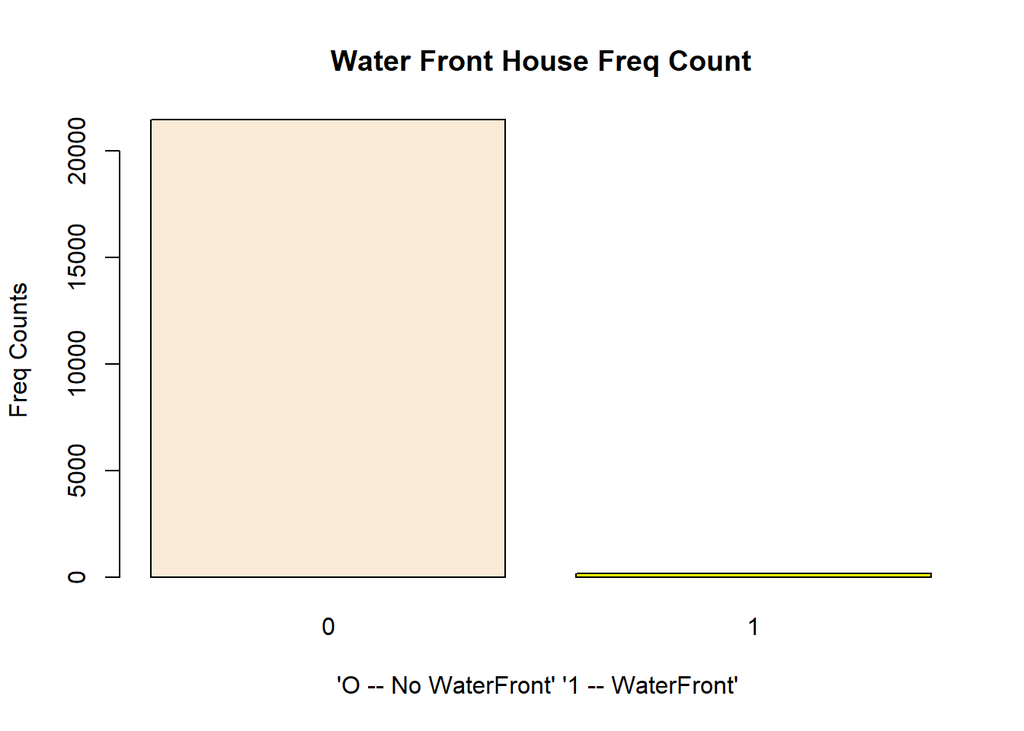

```r
library(plyr)
library(MASS)
waterfrong = fulldata$waterfront
waterfrong.freq = table(waterfrong)
colors = c("antiquewhite", "yellow", "green", "violet",
           "orange", "blue", "pink", "cyan")
barplot((waterfrong.freq),main="Water Front House Freq Count",
        xlab="'O -- No WaterFront' '1 -- WaterFront' ",
        ylab="Freq Counts",col=colors)
```

Grade

```r
Gradeb = fulldata$grade
Gradeb.freq = table(Gradeb)
Gradeb.freq
```

```
## Gradeb
##    1    3    4    5    6    7    8    9   10   11   12   13
##    1    3   29  242 2038 8980 6068 2615 1134  399   90   13
```

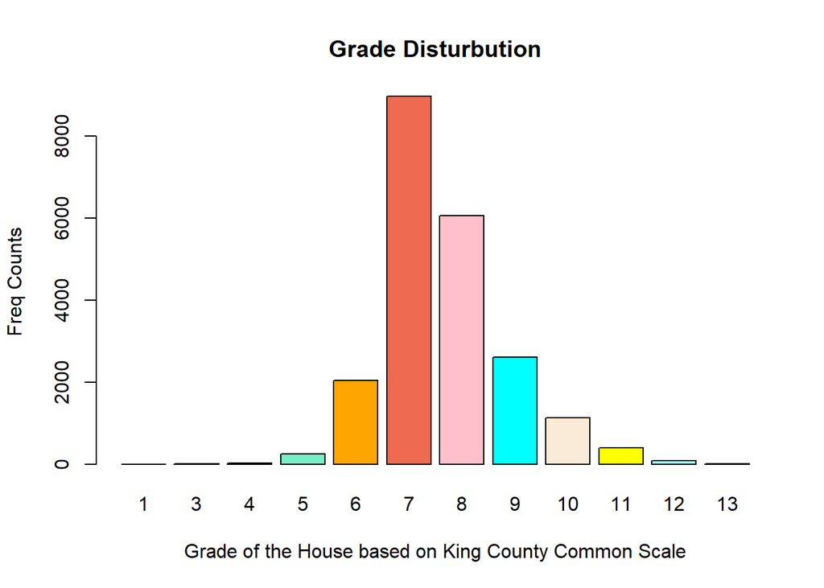

```r
colors = c("antiquewhite", "yellow", "cadetblue1", "aquamarine2",
           "orange", "coral2", "pink", "cyan")
barplot((Gradeb.freq),main="Grade Disturbution",
        xlab="Grade of the House based on King County Common Scale",
      ylab="Freq Counts",col=colors)
```

View

```r
View1 = fulldata$view
View1.freq = table(View1)
View1.freq
```

```
## View1
##     0     1     2     3     4
## 19488   332   963   510   319
```

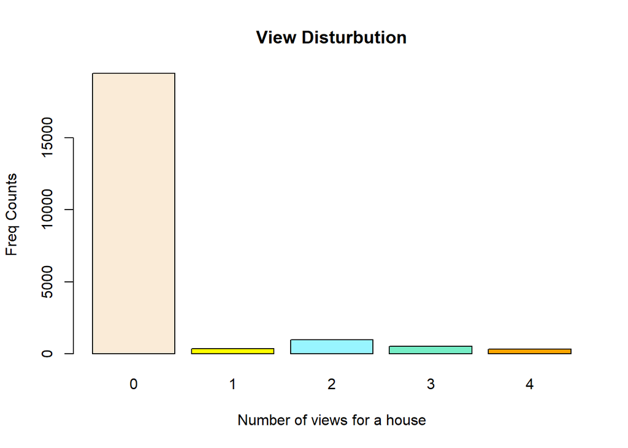

```r
colors = c("antiquewhite", "yellow", "cadetblue1", "aquamarine2",
           "orange")
barplot((View1.freq),main="View Disturbution",
        xlab="Number of views for a house",
        ylab="Freq Counts",col=colors)
```

Condition

```r
condition1 = fulldata$condition
condition1.freq = table(condition1)
condition1.freq
```

```
## condition1
##     1     2     3     4     5
##    30   172 14031  5679  1700
```

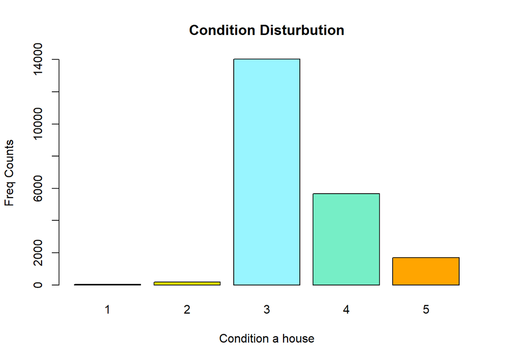

```r
colors = c("antiquewhite", "yellow", "cadetblue1", "aquamarine2",
           "orange")
barplot((condition1.freq),main="Condition Disturbution",
        xlab="Condition a house",
        ylab="Freq Counts",col=colors)
```

##Analysing the frequency of ordinal variables##

```r
library(car)
count(mtcars,'fulldata$view')
```

```
##   fulldata.view  freq
## 1             0 19488
## 2             1   332
## 3             2   963
## 4             3   510
## 5             4   319
```

```r
count(mtcars,'fulldata$waterfront')
```

```
##   fulldata.waterfront  freq
## 1                   0 21449
## 2                   1   163
```

```r
count(mtcars,'fulldata$condition')
```

```
##   fulldata.condition  freq
## 1                  1    30
## 2                  2   172
## 3                  3 14031
## 4                  4  5679
## 5                  5  1700
```

```r
count(mtcars,'fulldata$grade')
```

```
##    fulldata.grade freq
## 1               1    1
## 2               3    3
## 3               4   29
## 4               5  242
## 5               6 2038
## 6               7 8980
## 7               8 6068
## 8               9 2615
## 9              10 1134
## 10             11  399
## 11             12   90
## 12             13   13
```

```r
count(mtcars,'fulldata$floors')
```

```
##   fulldata.floors  freq
## 1             1.0 10679
## 2             1.5  1910
## 3             2.0  8241
## 4             2.5   161
## 5             3.0   613
## 6             3.5     8
```

```r
count(mtcars,'fulldata$bedroom')
```

```
##    fulldata.bedroom freq
## 1                 0   13
## 2                 1  199
## 3                 2 2760
## 4                 3 9824
## 5                 4 6882
## 6                 5 1601
## 7                 6  272
## 8                 7   38
## 9                 8   13
## 10                9    6
## 11               10    3
## 12               11    1
```

##Exploratory Anlysis for y variable price##

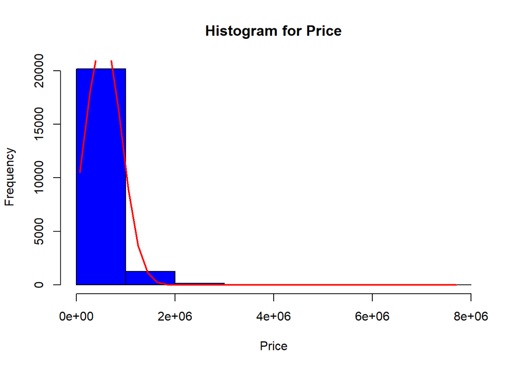

```r
x<-fulldata$price
h<-hist(x, breaks=10, col="Blue", xlab="Price",
        main="Histogram for Price")
xfit<-seq(min(x),max(x),length=40)
yfit<-dnorm(xfit,mean=mean(x),sd=sd(x))
yfit <- yfit*diff(h$mids[1:2])*length(x)
lines(xfit, yfit, col="Red", lwd=2)
```

Applying log transformations on y variable

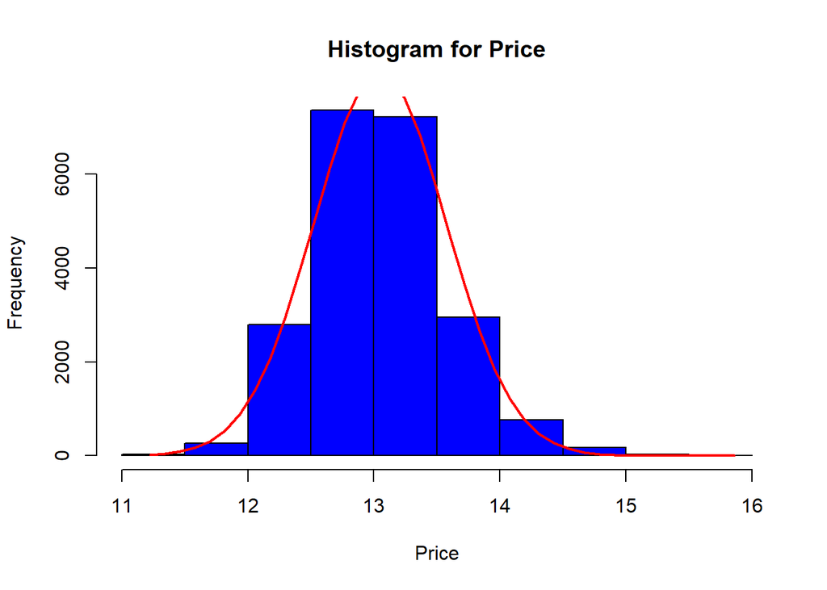

```r
x<-log(fulldata$price)
h<-hist(x, breaks=10, col="Blue", xlab="Price",
        main="Histogram for Price")
xfit<-seq(min(x),max(x),length=40)
yfit<-dnorm(xfit,mean=mean(x),sd=sd(x))
yfit <- yfit*diff(h$mids[1:2])*length(x)
lines(xfit, yfit, col="Red", lwd=2)
```

##Extracting the required variables to fulldata##

```r
data1<-fulldata[c(2,3,13,14,15,18,19,20,21,22,31,33,34,35)]
```

##Pearson correlation matrix##

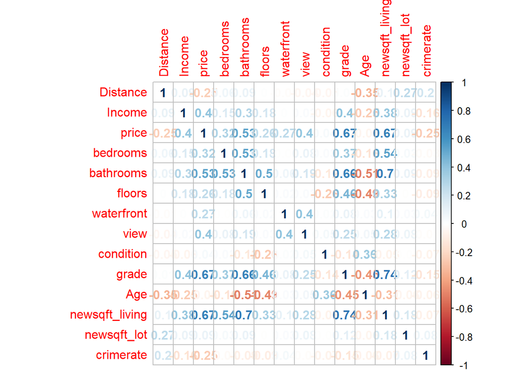

```r
library(corrplot)
c<-cor(data1)
corrplot(c,method="number")
```

##Scatter plot for each X and Variable ##

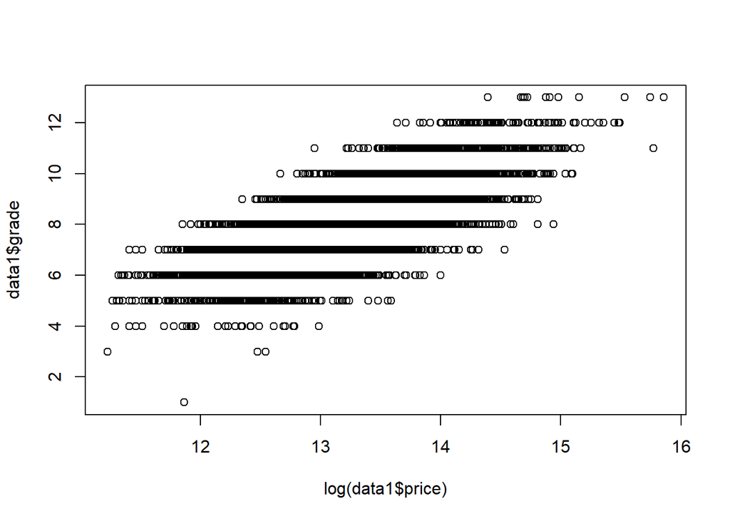

```r
library(car)
plot(log(data1$price),data1$grade)
```

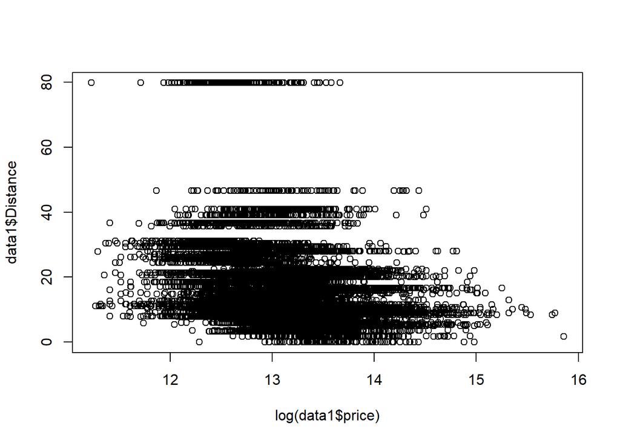

```r
plot(log(data1$price),data1$Distance)
```

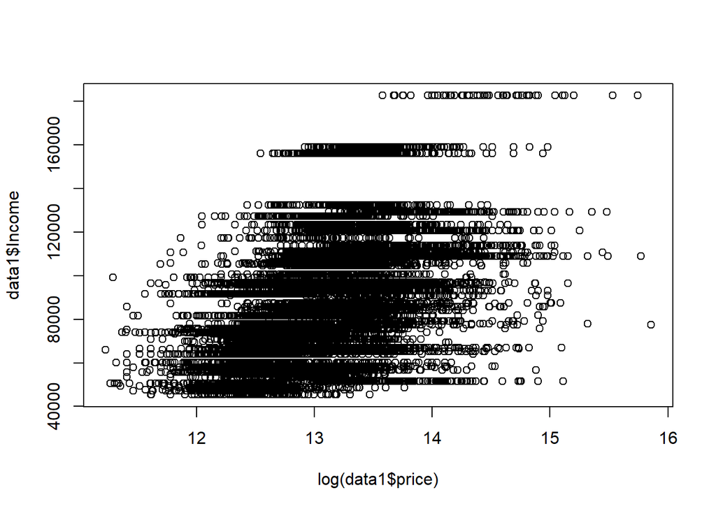

```r
plot(log(data1$price),data1$Income)
```

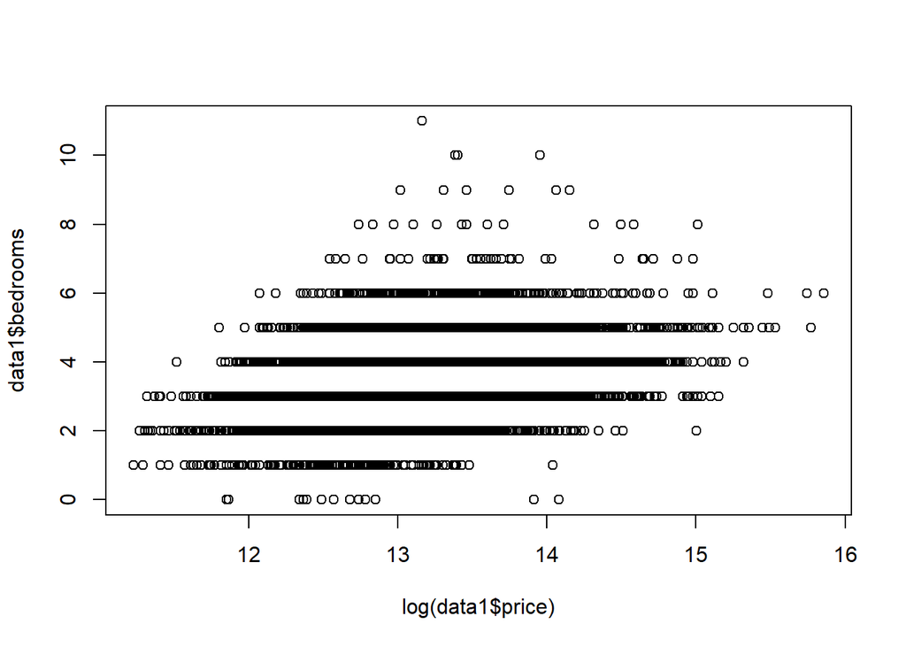

```r
plot(log(data1$price),data1$bedrooms)
```

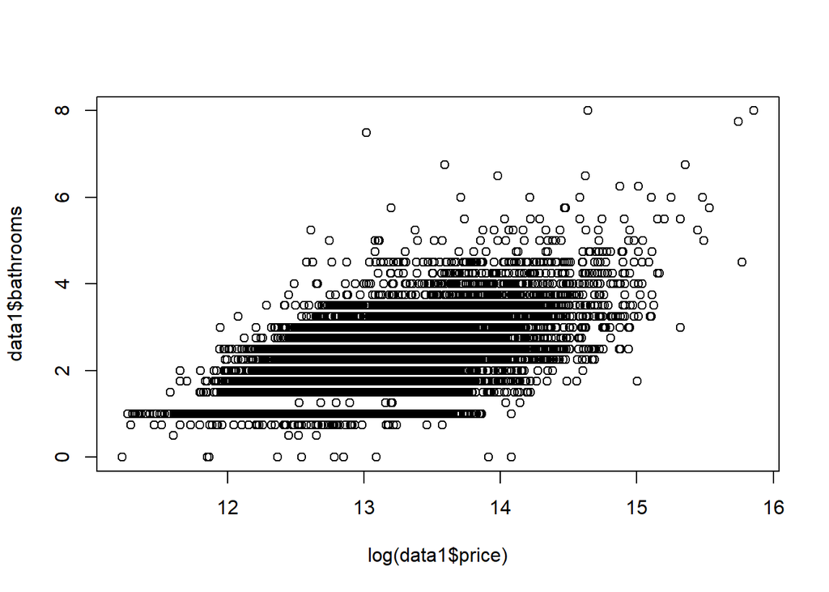

```r
plot(log(data1$price),data1$bathrooms)
```

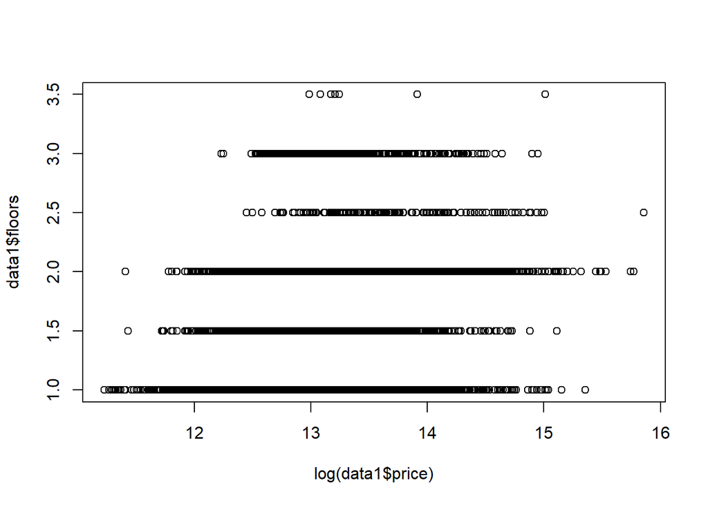

```r
plot(log(data1$price),data1$floors)
```

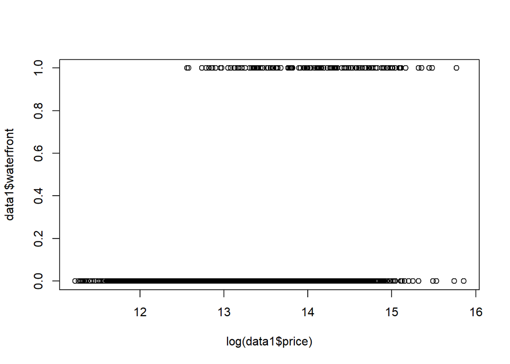

```r
plot(log(data1$price),data1$waterfront)
```

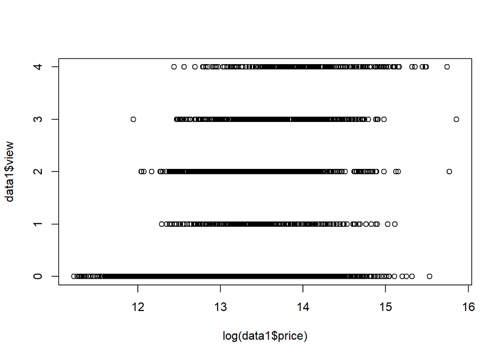

```r
plot(log(data1$price),data1$view)
```

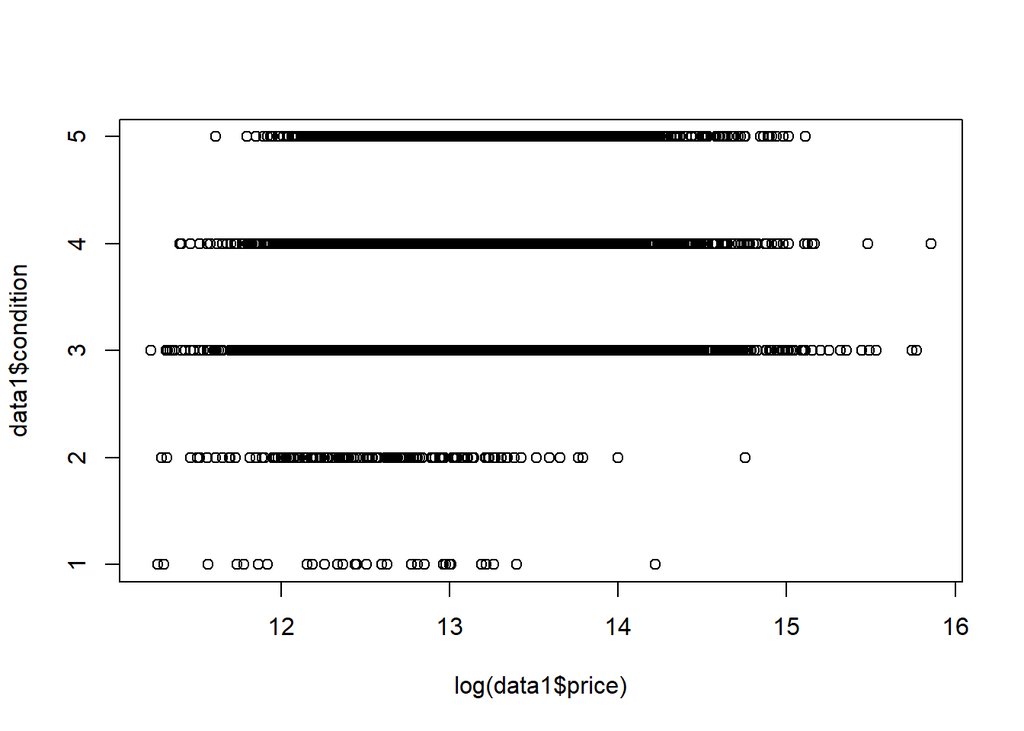

```r
plot(log(data1$price),data1$condition)
```

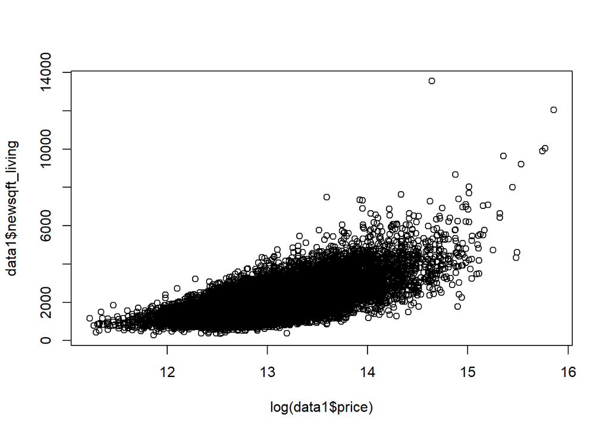

```r
plot(log(data1$price),data1$newsqft_living)
```

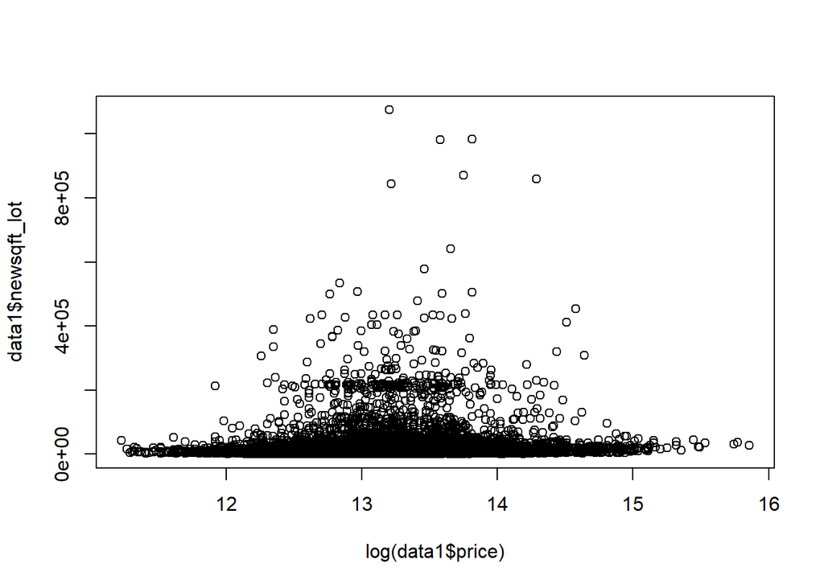

```r
plot(log(data1$price),data1$newsqft_lot)
```

##Splitting Training and Testing Data##

```r
selectfulldata = sample(1:nrow(fulldata),0.80*nrow(fulldata));
train1.data = data1[selectfulldata,];
test1.data = data1[-selectfulldata,];
str(train1.data)
```

```
## 'data.frame':    17289 obs. of  14 variables:
##  $ Distance      : num  11.13 8.05 21.41 21.41 21.41 ...
##  $ Income        : num  50680 58374 95717 95717 95717 ...
##  $ price         : int  280000 382500 200000 551500 302000 550000 335000 352000 690000 357000 ...
##  $ bedrooms      : int  4 2 5 4 5 3 3 2 2 5 ...
##  $ bathrooms     : num  3 1 1.75 2.5 2 1.75 1.75 0.75 1 2.5 ...
##  $ floors        : num  1 1 1 2 1 1.5 1 1 1 2 ...
##  $ waterfront    : int  0 0 0 0 0 0 0 0 0 0 ...
##  $ view          : int  0 0 0 0 0 0 0 0 0 0 ...
##  $ condition     : int  3 3 4 3 4 3 4 4 4 3 ...
##  $ grade         : int  8 6 7 9 7 7 7 4 7 8 ...
##  $ Age           : int  6 37 59 12 58 118 40 87 111 31 ...
##  $ newsqft_living: int  1730 1190 1770 2950 1540 1380 2430 760 970 2750 ...
##  $ newsqft_lot   : int  7500 4440 15525 10003 9629 3402 9133 33801 4560 12350 ...
##  $ crimerate     : num  0.05 0 0.02 0.02 0.02 0 0.02 0.02 0 0 ...
```

##Linear Regression Model##

Removed non significiant variables -condition,squareftlot,view,waterfront

```r
model1 <- lm(formula=log(price)~bathrooms+grade+bedrooms+floors
         +newsqft_living+crimerate+Distance,data=train1.data)
summary(model1)
```

```
##
## Call:
## lm(formula = log(price) ~ bathrooms + grade + bedrooms + floors +
##     newsqft_living + crimerate + Distance, data = train1.data)
##
## Residuals:
##      Min       1Q   Median       3Q      Max
## -1.93396 -0.18207  0.00384  0.17511  1.29398
##
## Coefficients:
##                  Estimate Std. Error t value Pr(>|t|)
## (Intercept)     1.155e+01  1.924e-02 600.212  < 2e-16 ***
## bathrooms       4.892e-02  4.680e-03  10.453  < 2e-16 ***
## grade           1.692e-01  3.068e-03  55.155  < 2e-16 ***
## bedrooms       -3.701e-04  3.049e-03  -0.121    0.903
## floors         -3.525e-02  4.859e-03  -7.254 4.23e-13 ***
## newsqft_living  2.284e-04  4.473e-06  51.053  < 2e-16 ***
## crimerate      -4.703e+00  1.169e-01 -40.234  < 2e-16 ***
## Distance       -1.415e-02  1.938e-04 -73.029  < 2e-16 ***
## ---
## Signif. codes:  0 '***' 0.001 '**' 0.01 '*' 0.05 '.' 0.1 ' ' 1
##
## Residual standard error: 0.29 on 17281 degrees of freedom
## Multiple R-squared:  0.6945, Adjusted R-squared:  0.6944
## F-statistic:  5612 on 7 and 17281 DF,  p-value: < 2.2e-16
```

Removing bedroms as it is not significant

```r
model2 <- lm(formula=log(price)~bathrooms+grade+floors
           +newsqft_living+crimerate+Distance,data=train1.data)
summary(model2)
```

```
##
## Call:
## lm(formula = log(price) ~ bathrooms + grade + floors + newsqft_living +
##     crimerate + Distance, data = train1.data)
##
## Residuals:
##      Min       1Q   Median       3Q      Max
## -1.93275 -0.18197  0.00376  0.17520  1.29426
##
## Coefficients:
##                  Estimate Std. Error t value Pr(>|t|)
## (Intercept)     1.155e+01  1.750e-02  659.70  < 2e-16 ***
## bathrooms       4.875e-02  4.472e-03   10.90  < 2e-16 ***
## grade           1.693e-01  3.048e-03   55.54  < 2e-16 ***
## floors         -3.520e-02  4.841e-03   -7.27 3.74e-13 ***
## newsqft_living  2.282e-04  4.275e-06   53.38  < 2e-16 ***
## crimerate      -4.703e+00  1.169e-01  -40.24  < 2e-16 ***
## Distance       -1.415e-02  1.938e-04  -73.03  < 2e-16 ***
## ---
## Signif. codes:  0 '***' 0.001 '**' 0.01 '*' 0.05 '.' 0.1 ' ' 1
##
## Residual standard error: 0.2899 on 17282 degrees of freedom
## Multiple R-squared:  0.6945, Adjusted R-squared:  0.6944
## F-statistic:  6548 on 6 and 17282 DF,  p-value: < 2.2e-16
```

##Models using step wise regression##